# Regression Analysis

[figure not shown]

## What is Regression?

Regression predicts a numerical outcome (“dependent variable”) from a set of inputs (“independent variables”).

- Statistical Sense: Predicting the expected value of the outcome.
- Casual Sense: Predicting a numerical outcome, rather than a discrete one.
- Scientific Mindset: Modeling to understand the data generation process.

## Identify the Regression Tasks

From a machine learning perspective, the term regression generally encompasses the prediction of continuous values. Statistically, these predictions are the expected value, or the average value one would observe for the given input values.

Which of the following tasks are regression problems?

- Predict (yes/no) whether a student will pass the final exam, given scores on midterms and homework.
- Predict the student’s score (0 - 100) on the final exam, given scores on midterms and homework. (Correct)
- Predict the student’s final grade (A, B, C, D, F) in the class given scores on midterms and homework (before they’ve taken the final exam).

## Code a Simple Linear Regression

For the first coding exercise, you’ll create a formula to define a one-variable modeling task, and then fit a linear model to the data. You are given the rates of male and female unemployment in the United States over several years. [(Unemployment Data)](https://college.cengage.com/mathematics/brase/understandable_statistics/7e/students/datasets/slr/excel/slr04.xls).

The task is to predict the rate of female unemployment from the observed rate of male unemployment. The outcome is `female_unemployment`, and the input is `male_unemployment.`

The sign of the variable coefficient tells you whether the outcome increases (+) or decreases (-) as the variable increases.  
Recall the calling interface for `lm()` is: `lm(formula, data = ___)`

```r
library(tidyverse)
```

```r
# unemployment is loaded in the workspace
head(unemployment)
```

| male_unemployment | female_unemployment |
| --- | --- |
| 2.9 | 4.0 |
| 6.7 | 7.4 |
| 4.9 | 5.0 |
| 7.9 | 7.2 |
| 9.8 | 7.9 |
| 6.9 | 6.1 |

```r
# Define a formula to express female_unemployment as a function of male_unemployment
(fmla <- as.formula(female_unemployment ~ male_unemployment))
```

```
female_unemployment ~ male_unemployment
```

```r
# Use the formula to fit a model: unemployment_model
(unemployment_model <- lm(formula = fmla,
                         data = unemployment))
```

```
Call:
lm(formula = fmla, data = unemployment)

Coefficients:
      (Intercept)  male_unemployment
           1.4341             0.6945
```

The coefficient for male unemployment is positive, so female unemployment increases as male unemployment does. Linear regression is the most basic of regression approaches. You can think of this course as ways to address its limitations.

## Examining a Model

Let’s look at the model `unemployment_model` that you have just created. There are a variety of different ways to examine a model; each way provides different information. We will use `summary()`, `broom::glance()`, and `sigr::wrapFTest()`.

```r
library(broom)
library(sigr)

# Print unemployment_model
unemployment_model
```

```
Call:
lm(formula = fmla, data = unemployment)

Coefficients:
      (Intercept)  male_unemployment
           1.4341             0.6945
```

```r
# Call summary() on unemployment_model to get more details. In addition to the coefficient values, you get standard errors on the coefficient estimates, and some goodness-of-fit metrics like R-squared.
summary(unemployment_model)
```

```
Call:
lm(formula = fmla, data = unemployment)

Residuals:
     Min       1Q   Median       3Q      Max
-0.77621 -0.34050 -0.09004  0.27911  1.31254

Coefficients:
                  Estimate Std. Error t value Pr(>|t|)
(Intercept)        1.43411    0.60340   2.377   0.0367 *
male_unemployment  0.69453    0.09767   7.111 1.97e-05 ***
---
Signif. codes:  0 '***' 0.001 '**' 0.01 '*' 0.05 '.' 0.1 ' ' 1

Residual standard error: 0.5803 on 11 degrees of freedom
Multiple R-squared:  0.8213,    Adjusted R-squared:  0.8051
F-statistic: 50.56 on 1 and 11 DF,  p-value: 1.966e-05
```

```r
# Call wrapFTest() on unemployment_model to see the most relevant details
wrapFTest(unemployment_model)
```

```
[1] "F Test summary: (R2=0.8213, F(1,11)=50.56, p=1.966e-05)."
```

There are several different ways to get diagnostics for your model. Use the one that suits your needs or preferences the best.

## Predicting using a Model

In this exercise, you will use your `unemployment_model` to make predictions from the `unemployment` data, and compare predicted female unemployment rates to the actual observed female unemployment rates on the training data, `unemployment`. You will also use your model to predict on the new data in `newrates`, which consists of only one observation, where male unemployment is 5%.

The `predict()` interface for `lm` models takes the form `predict(model, newdata)`

You will use the `ggplot2` package to make the plots, so you will add the prediction column to the `unemployment` data frame. You will plot outcome versus prediction, and compare them to the line that represents perfect predictions (that is when the outcome is equal to the predicted value).

The `ggplot2` command to plot a scatterplot of `dframe$outcome` versus `dframe$pred` (`pred` on the x axis, `outcome` on the y axis), along with a blue line where `outcome == pred` is as follows:

`ggplot(dframe, aes(x = pred, y = outcome)) +`  
`geom_point() +`  
`geom_abline(color = "blue")`

```r
# unemployment is in your workspace
head(unemployment)
```

| male_unemployment | female_unemployment |
| --- | --- |
| 2.9 | 4.0 |
| 6.7 | 7.4 |
| 4.9 | 5.0 |
| 7.9 | 7.2 |
| 9.8 | 7.9 |
| 6.9 | 6.1 |

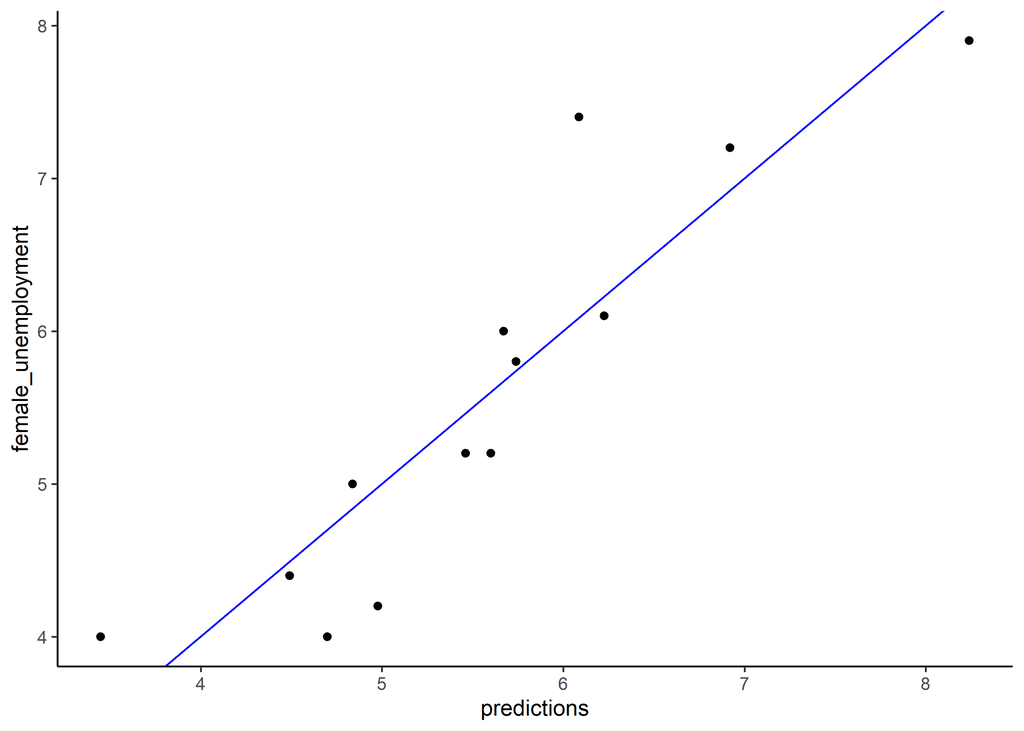

```r
# Predict female unemployment in the unemployment data set
unemployment$predictions <-  predict(object = unemployment_model,
                                    newdata = unemployment)

# Make a plot to compare predictions to actual (prediction on x axis).
ggplot(unemployment,
       aes(x = predictions,
           y = female_unemployment)) +
  geom_point() +
  geom_abline(color = "blue") +
  theme_classic()
```

```r
# Predict female unemployment rate when male unemployment is 5%
newrates <- data.frame(male_unemployment = 5)
pred <- predict(object = unemployment_model,
                newdata = newrates)
# Print it
pred
```

```
       1
4.906757
```

## Multivariate Linear Regression - Model Building

In this exercise, you will work with the `blood pressure` dataset (Source), and model `blood_pressure` as a function of `age` and `weight`. [(Blood Pressure)](https://college.cengage.com/mathematics/brase/understandable_statistics/7e/students/datasets/mlr/excel/mlr02.xls)

```r
# bloodpressure is in the workspace
head(bloodpressure)
```

| blood_pressure | age | weight |
| --- | --- | --- |
| 132 | 52 | 173 |
| 143 | 59 | 184 |
| 153 | 67 | 194 |
| 162 | 73 | 211 |
| 154 | 64 | 196 |
| 168 | 74 | 220 |

```r
# Create the formula and print it
fmla <- as.formula(blood_pressure ~ age + weight)
fmla
```

```
blood_pressure ~ age + weight
```

```r
# Fit the model: bloodpressure_model
bloodpressure_model <- lm(formula = fmla,
                          data = bloodpressure)

# Print bloodpressure_model
bloodpressure_model
```

```
Call:
lm(formula = fmla, data = bloodpressure)

Coefficients:
(Intercept)          age       weight
    30.9941       0.8614       0.3349
```

```r
# Call summary() on bloodpressure_model
summary(bloodpressure_model)
```

```
Call:
lm(formula = fmla, data = bloodpressure)

Residuals:
    Min      1Q  Median      3Q     Max
-3.4640 -1.1949 -0.4078  1.8511  2.6981

Coefficients:
            Estimate Std. Error t value Pr(>|t|)
(Intercept)  30.9941    11.9438   2.595  0.03186 *
age           0.8614     0.2482   3.470  0.00844 **
weight        0.3349     0.1307   2.563  0.03351 *
---
Signif. codes:  0 '***' 0.001 '**' 0.01 '*' 0.05 '.' 0.1 ' ' 1

Residual standard error: 2.318 on 8 degrees of freedom
Multiple R-squared:  0.9768,    Adjusted R-squared:  0.9711
F-statistic: 168.8 on 2 and 8 DF,  p-value: 2.874e-07
```

One of the advantages of linear regression is that you can interpret the effects of each variable on the input – to a certain extent. In this case the coefficients for both age and weight are positive, which indicates that bloodpressure tends to increase as both age and weight increase.

## Multivariate Linear Regression - Prediction

Now you will make predictions using the blood pressure model `bloodpressure_model` that you fit in the previous exercise. You will also compare the predictions to outcomes graphically. `ggplot2` is already loaded in your workspace. Recall the plot command takes the form:

`ggplot(dframe, aes(x = pred, y = outcome)) +`  
`geom_point() +`  
`geom_abline(color = "blue")`

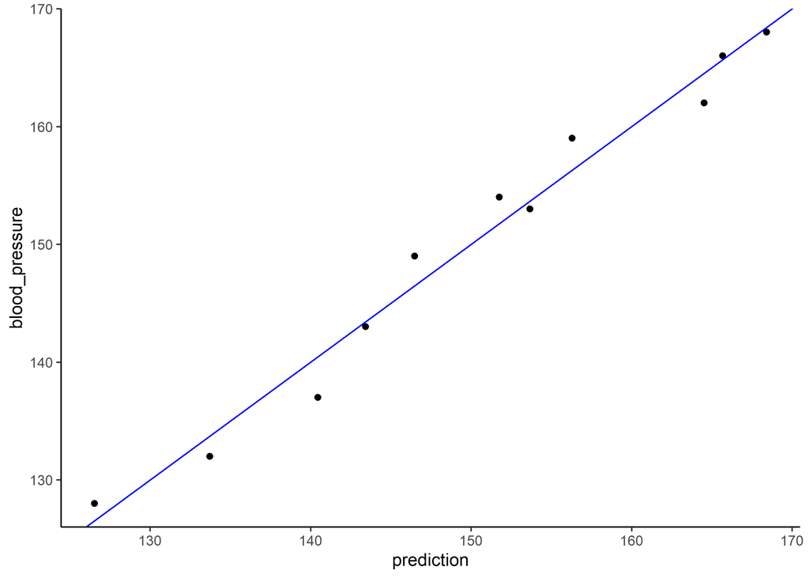

```r
# predict blood pressure using bloodpressure_model :prediction
bloodpressure$prediction <- predict(object = bloodpressure_model,
                                    newdata = bloodpressure)

# plot the results
ggplot(bloodpressure,
       aes(x = prediction,
           y = blood_pressure)) +
    geom_point() +
    geom_abline(color = "blue") +
    theme_classic()
```

The results stay fairly close to the line of perfect prediction, indicating that the model fits the training data well. From a prediction perspective, multivariate linear regression behaves much as simple (one-variable) linear regression does.

## Wrapping up Linear Regression

- Pros of Linear Regression
  - East to fit and apply
  - Concise
  - Less prone to overfitting
  - Interpretable
- Cons
  - Can only express Linear and Additive relationships
  - Problem of Collinearity (Coefficients might change sign)
  - Due to High Collinearity, model can become unstable

## Graphically Evaluate the Model

The Ground Truth vs Prediction plot is the one in which predictions are plotted on the x-axis and original variable is plotted on the y-axis.

In this plot, the line `x = y` represents the line of perfect prediction. If the model predicts perfectly, all of the points are along the line.

You should look for the points to be evenly above and below the line. This means that the errors are not correlated with the actual outcome.

When the model doesn’t fit well, there are regions where the points are entirely above or below the line. This demonstrates Systematic Errors: errors that are correlated with the outcome. This can indicate that you don’t have enough variables in the model or you need an algorithm that can fit more complex relationships in the data.

## Residuals Plot

A residual plot plots the residuals against predictions. In a model with no systematic errors, the errors are evenly distributed between positive and negative, annd have same magnitude above and below. When there are systematic errors, there are clusters of all positive and all negative residuals.

In this exercise, you will graphically evaluate the unemployment model, `unemployment_model`, that you fit to the `unemployment` data in the previous chapter. Recall that the model predicts `female_unemployment` from `male_unemployment`.

You will plot the model’s predictions against the actual `female_unemployment`; recall the command is of the form

`ggplot(dframe, aes(x = pred, y = outcome)) +`  
`geom_point() +`  
`geom_abline()`

Then you will calculate the residuals: `residuals <- actual outcome - predicted outcome`

and plot predictions against residuals. The residual graph will take a slightly different form: you compare the residuals to the horizontal line x=0 using `geom_hline()` rather than to the line x=y.

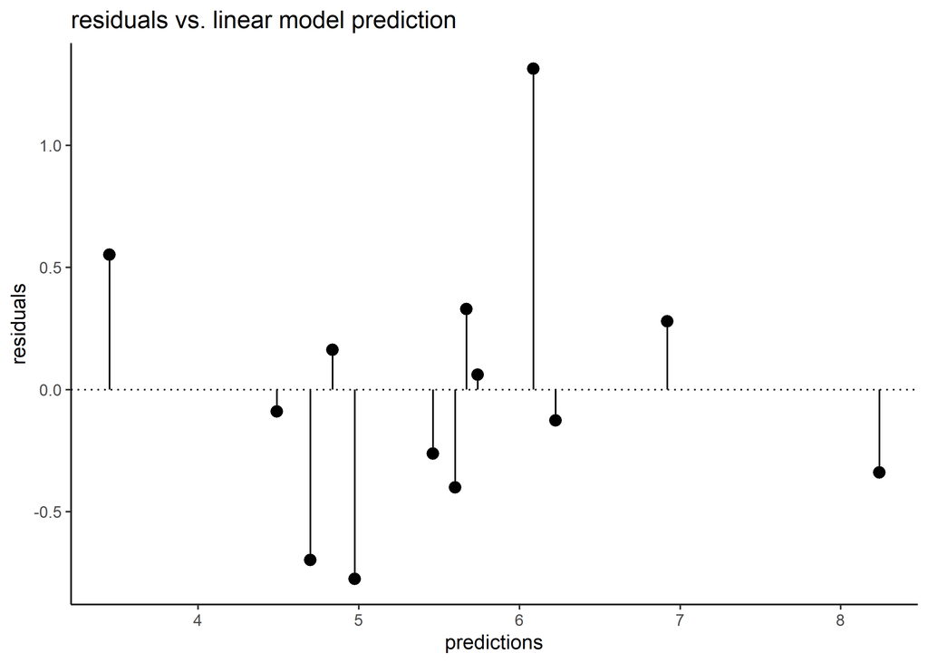

```r
# Calculate residuals
unemployment$residuals <- unemployment$female_unemployment - unemployment$predictions

ggplot(unemployment,
       aes(x = predictions,
           y = residuals)) +
  geom_pointrange(aes(ymin = 0, ymax = residuals)) +
  geom_hline(yintercept = 0, linetype = 3) +
  ggtitle("residuals vs. linear model prediction") +
  theme_classic()
```

You have now evaluated model predictions by comparing them to ground truth, and by examining prediction error.

## Gain Curve Plot

The Gain Curve Plot is useful when sorting the instances is more important than predicting the exact outcome value. The x-axis shows the fraction of predictions as sorted by the model. The y-axis shows the fraction of original outcome.

In the previous exercise you made predictions about `female_unemployment` and visualized the predictions and the residuals. Now, you will also plot the gain curve of the ’s predictions against actual `female_unemployment` using the `WVPlots::GainCurvePlot()` function.

For situations where order is more important than exact values, the gain curve helps you check if the model’s predictions sort in the same order as the true outcome.

Calls to the function `GainCurvePlot()` look like:

`GainCurvePlot(frame, xvar, truthvar, title)`

where * `frame` is a data frame * `xvar` and `truthvar` are strings naming the prediction and actual outcome columns of `frame` * `title` is the title of the plot

When the predictions sort in exactly the same order, the relative Gini coefficient is 1. When the model sorts poorly, the relative Gini coefficient is close to zero, or even negative.

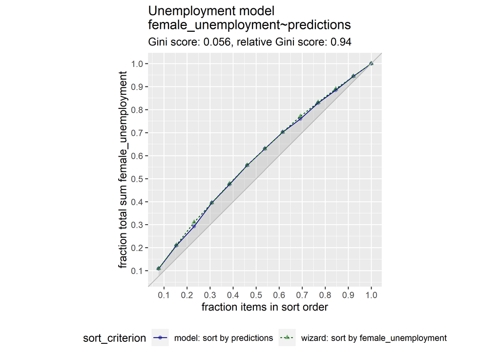

```r
# Load the package WVPlots
library(WVPlots)
# Plot the Gain Curve
GainCurvePlot(frame = unemployment,
              "predictions",
              "female_unemployment",
              "Unemployment model")
```

A relative gini coefficient close to one shows that the model correctly sorts high unemployment situations from lower ones.

## Root Mean Squared Error

Root Mean Squared Error is a key metric to evaluate prediction performance of a regression model.
$$RMSE = \sqrt{\overline{(pred - actual)^2}}$$

Compare the RMSE to the Standard Deviation of the outcome.

Standard Deviation is the average difference between the a value and it’s average.

If RMSE is less than Standard Deviation then it means that the model is better than just predicting the average value.

## Calculate RMSE

In this exercise you will calculate the RMSE of your unemployment model. In the previous coding exercises, you added two columns to the `unemployment` dataset:

- The model’s predictions (`predictions` column)
- The residuals between the predictions and the outcome (`residuals` column)

You can calculate the RMSE from a vector of residuals, res, as:
$$RMSE = \sqrt{mean(res^2)}$$

You want RMSE to be small. How small is “small”? One heuristic is to compare the RMSE to the standard deviation of the outcome. With a good model, the RMSE should be smaller.

An RMSE much smaller than the outcome’s standard deviation suggests a model that predicts well.

```r
# Calculate RMSE, assign it to the variable rmse and print it
rmse <- sqrt(mean(unemployment$residuals^2))
rmse
```

```
[1] 0.5337612
```

```r
# Calculate the standard deviation of female_unemployment and print it
sd_unemployment <- sd(unemployment$female_unemployment)
sd_unemployment
```

```
[1] 1.314271
```

## R-Squared

R-Square measures of how well the model fits or explains the data.

It takes values between 0 and 1.

- Near 1: Model fits the data well.
- Near 0: Models is no better than just guessing the average value.

$R^2$ is the variance explained by the model.
$$R^2 = 1 - \frac{RSS}{TSS}$$

Where;

- RSS: Residual Sum of Squares (Variance from the model)
- TSS: Total Sum of Squares (Variance from the data)

## Calculate R-Squared

Now that you’ve calculated the RMSE of your model’s predictions, you will examine how well the model fits the data: that is, how much variance does it explain. You can do this using $R^2$.

Suppose y is the true outcome, p is the prediction from the model, and res=y−p are the residuals of the predictions.

Then the Total Sum of Squares: TSS (“total variance”) of the data is:
$$TSS = \sum(y - \overline{y})^2$$

The Residual Sum of Squared errors of the model, RSS is:
$$RSS = \sum(y_{actual} - y_{pred})^2$$

After you calculate $R^2$, you will compare what you computed with the $R^2$ reported by `glance()`. `glance()` returns a one-row data frame; for a linear regression model, one of the columns returned is the R2 of the model on the training data.

The data frame `unemployment` is in your workspace, with the columns `predictions` and `residuals` that you calculated in a previous exercise.

```r
# Calculate mean female_unemployment: fe_mean. Print it
(fe_mean <- mean(unemployment$female_unemployment))
```

```
[1] 5.569231
```

```r
# Calculate total sum of squares: tss. Print it
(tss <- sum((unemployment$female_unemployment - mean(unemployment$female_unemployment))^2))
```

```
[1] 20.72769
```

```r
# Calculate residual sum of squares: rss. Print it
(rss <- sum(unemployment$residuals^2))
```

```
[1] 3.703714
```

```r
# Calculate R-squared: rsq. Print it. Is it a good fit?
(rsq <- 1 - (rss)/(tss))
```

```
[1] 0.8213157
```

```r
# Get R-squared from glance. Print it
(rsq_glance <- glance(unemployment_model)$r.squared)
```

```
[1] 0.8213157
```

## Correlation and R-squared

The linear correlation of two variables, x and y, measures the strength of the linear relationship between them. When x and y are respectively:

- The outcomes of a regression model that minimizes squared-error (like linear regression) and
- The true outcomes of the training data,

then the square of the correlation is the same as $R^2$. You will verify that in this exercise.

```r
# Get the correlation between the prediction and true outcome: rho and print it
(rho <- cor(unemployment$predictions,
            unemployment$female_unemployment))
```

```
[1] 0.9062647
```

```r
# Square rho: rho2 and print it
(rho2 <- rho^2)
```

```
[1] 0.8213157
```

```r
# Get R-squared from glance and print it
(rsq_glance <- glance(unemployment_model)$r.squared)
```

```
[1] 0.8213157
```

Remember this equivalence is only true for the training data, and only for models that minimize squared error.

## Properly Training a Model

Model can perform much better on the training data than the data the model hasn’t seen. To overcome this and evaluate your model on unseen data. Split the data into 2 parts viz. Training data and Testing data. Evaluate the performance of the model on the Testing data.

## Generating a Random Test/Train Split

For the next several exercises you will use the `mpg` data from the package `ggplot2.` The data describes the characteristics of several makes and models of cars from different years. The goal is to predict city fuel efficiency from highway fuel efficiency.

In this exercise, you will split `mpg` into a training set `mpg_train` (75% of the data) and a test set `mpg_test` (25% of the data). One way to do this is to generate a column of uniform random numbers between 0 and 1, using the function `runif()`.

If you have a data set of size N, and you want a random subset of approximately size $100\times X$% of N (where X is between 0 and 1), then:

1. Generate a vector of uniform random numbers: `gp = runif(N)`.
2. `dframe[gp < X,]` will be about the right size.
3. `dframe[gp >= X,]` will be the complement.

```r
# Loading mpg data
data("mpg")
dim(mpg)
```

```
[1] 234  11
```

```r
# Use nrow to get the number of rows in mpg (N) and print it
(N <- nrow(mpg))
```

```
[1] 234
```

```r
# Calculate how many rows 75% of N should be and print it
# Hint: use round() to get an integer
(target <- round(0.75 * N))
```

```
[1] 176
```

```r
# Create the vector of N uniform random variables: gp
gp <- runif(N)

# Use gp to create the training set: mpg_train (75% of data) and mpg_test (25% of data)
mpg_train <- mpg[gp < 0.75,]
mpg_test <- mpg[gp >= 0.75,]

# Use nrow() to examine mpg_train and mpg_test
nrow(mpg_train)
```

```
[1] 179
```

```r
nrow(mpg_test)
```

```
[1] 55
```

## Train a model using Test/Train Split

Now that you have split the `mpg` dataset into `mpg_train` and `mpg_test`, you will use `mpg_train` to train a model to predict city fuel efficiency (`cty`) from highway fuel efficiency (`hwy`).

```r
# Create a formula to express cty as a function of hwy: fmla and print it.
(fmla <- formula(cty ~ hwy))
```

```
cty ~ hwy
```

```r
# Now use lm() to build a model mpg_model from mpg_train that predicts cty from hwy
mpg_model <- lm(formula = fmla,
                data = mpg_train)

# Use summary() to examine the model
summary(mpg_model)
```

```
Call:
lm(formula = fmla, data = mpg_train)

Residuals:
    Min      1Q  Median      3Q     Max
-2.8228 -0.8150 -0.1449  0.5174  2.5174

Coefficients:
            Estimate Std. Error t value Pr(>|t|)
(Intercept)  1.13447    0.37178   3.051  0.00263 **
hwy          0.66754    0.01559  42.810  < 2e-16 ***
---
Signif. codes:  0 '***' 0.001 '**' 0.01 '*' 0.05 '.' 0.1 ' ' 1

Residual standard error: 1.199 on 177 degrees of freedom
Multiple R-squared:  0.9119,    Adjusted R-squared:  0.9114
F-statistic:  1833 on 1 and 177 DF,  p-value: < 2.2e-16
```

## Evaluate a Model using Test/Train Split

Now you will test the model `mpg_model` on the test data, `mpg_test.` Functions `rmse()` and `r_squared()` to calculate RMSE and R-squared have been provided for convenience:

`rmse(predcol, ycol)` `r_squared(predcol, ycol)`

where:

- predcol: The predicted values
- ycol: The actual outcome

You will also plot the predictions vs. the outcome.

Generally, model performance is better on the training data than the test data (though sometimes the test set “gets lucky”). A slight difference in performance is okay; if the performance on training is significantly better, there is a problem.

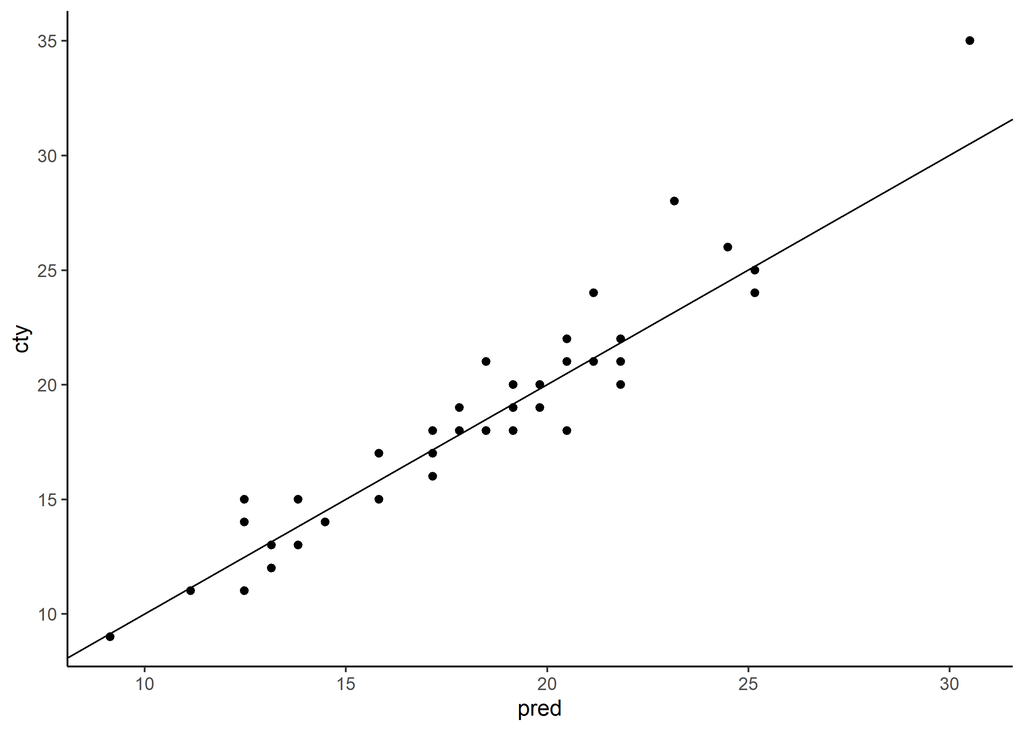

```r
# predict cty from hwy for the training set
mpg_train$pred <- predict(object = mpg_model,
                          newdata = mpg_train)

# predict cty from hwy for the test set
mpg_test$pred <- predict(object = mpg_model,
                         newdata = mpg_test)

# Evaluate the rmse on both training and test data and print them
# (rmse_train <- rmse(predcol = mpg_train$pred,
#                     ycol = mpg_train$cty))
# (rmse_test <- rmse(predcol = mpg_test$pred,
#                    ycol = mpg_test$cty))


# Evaluate the r-squared on both training and test data.and print them
# (rsq_train <- r_squared(predcol = mpg_train$pred,
#                         ycol = mpg_train$cty))
# (rsq_test <- r_squared(predcol = mpg_test$pred,
#                        ycol = mpg_test$cty))

# Plot the predictions (on the x-axis) against the outcome (cty) on the test data
ggplot(mpg_test,
       aes(x = pred,
           y = cty)) +
  geom_point() +
  geom_abline() +
  theme_classic()
```

Good performance on the test data is more confirmation that the model works as expected.